# TP6 — Principal Component Analysis (PCA) part 3

Biplots, UMAP, limitations of PCA - Breast cancer subtypes

Massimo Andreatta

2026-07-23

> **How to use this notebook.** You do **not** need any programming experience. Read each short explanation, then press the green *play* button (▶) at the top-right of each grey *code chunk* to run it. Look at the output, and answer the **Questions** in the green boxes (write your answers in plain text under each one). The goal is to *understand the data and the method*, not to memorise code.

> **Building on TP4 and TP5.** This notebook assumes familiarity with the basic PCA workflow (data preparation, standardisation, scree plot, PCA plot, loadings) from TP4 and TP5. Here we focus on three new themes: the **biplot** — a single figure combining patient positions and variable directions; **UMAP** — a non-linear alternative to PCA; and the **limitations** of PCA that every user should keep in mind.

# The dataset: breast cancer gene expression (TCGA-BRCA)

## Background: breast cancer is not one disease

For decades, breast cancer was treated largely as a single disease. In the early 2000s, gene-expression profiling revealed that breast cancer comprises at least **four molecularly distinct subtypes** with very different biology, prognosis, and treatment response:

| Subtype | Key biology | Hormone receptors | Prognosis |
| --- | --- | --- | --- |
| **Luminal A** (LumA) | ER/PR-positive, low proliferation | ER+, PR+ | Best |
| **Luminal B** (LumB) | ER/PR-positive, higher proliferation | ER+/−, PR+/− | Intermediate |
| **HER2-enriched** (Her2) | HER2 gene amplification | HER2+, often ER− | Variable |
| **Basal-like** (Basal) | Triple-negative, high genomic instability | ER−, PR−, HER2− | Worst |
| **Normal-like** | Gene pattern resembles normal breast tissue | Variable | Intermediate |

The **PAM50** test (Parker *et al.* 2009, *J Clin Oncol*) is a clinical assay that measures 50 carefully selected genes and assigns each tumour to one of these subtypes. It is used clinically to guide treatment decisions and predict the benefit of chemotherapy.

## The 50 PAM50 genes and what they measure

The 50 genes span several biological programmes:

| Biological role | Key genes |
| --- | --- |
| Oestrogen / hormone signalling | *ESR1*, *PGR*, *NAT1*, *FOXA1*, *BCL2*, *SLC39A6* |
| HER2 / growth factor signalling | *ERBB2*, *GRB7*, *FGFR4*, *MMP11* |
| Basal / myoepithelial markers | *KRT5*, *KRT14*, *KRT17*, *EGFR*, *CDH3*, *FOXC1* |
| Cell proliferation | *MKI67*, *CCNB1*, *CCNE1*, *CDC6*, *CDC20*, *RRM2*, *BIRC5* |
| Other structural / signalling | *MDM2*, *MYC*, *MELK*, *CENPF*, … |

Expression values are on a **log₂ scale** (log₂ of normalised RNA-seq counts). All 50 genes are already on the same numeric scale, so no further log-transformation is needed. We will still need to **standardise** them before PCA (see section 2).

## Load the data

```r
brca <- read.csv("../data/brca_pam50.csv", row.names = 1)
head(brca[, 1:8])   # show first few columns
```

```
##                 pam50 er_status pr_status her2_status age      stage   NDC80
## TCGA-A1-A0SD-01  LumA  Positive  Positive    Negative  59  Stage IIA  6.4322
## TCGA-A1-A0SE-01  LumA  Positive  Positive    Negative  56    Stage I  7.7695
## TCGA-A1-A0SH-01  LumA  Negative  Positive    Negative  39  Stage IIA  6.3236
## TCGA-A1-A0SJ-01  LumA  Positive  Positive    Negative  39 Stage IIIA  7.0911
## TCGA-A1-A0SK-01 Basal  Negative  Negative    Negative  54  Stage IIA 10.4276
## TCGA-A1-A0SM-01  LumB  Positive  Negative    Positive  77  Stage IIA  8.1424
##                   ERBB2
## TCGA-A1-A0SD-01 13.6648
## TCGA-A1-A0SE-01 13.1849
## TCGA-A1-A0SH-01 14.1351
## TCGA-A1-A0SJ-01 13.1853
## TCGA-A1-A0SK-01  8.2503
## TCGA-A1-A0SM-01 17.4937
```

```r
# Gene expression columns
gene_cols <- colnames(brca)[7:56]

# Colour palette for PAM50 subtypes
subtype_cols <- c(
  LumA       = "#1f77b4",   # blue — best prognosis
  LumB       = "#aec7e8",   # light blue
  Her2       = "#ff7f0e",   # orange
  Basal      = "#d62728",   # red — worst prognosis
  NormalLike = "#7f7f7f"    # grey
)
```

# 1 — Meet the data

## Size and subtype distribution

```r
dim(brca)
```

```
## [1] 522  56
```

```r
cat("Samples per PAM50 subtype:\n")
```

```
## Samples per PAM50 subtype:
```

```r
table(brca$pam50)
```

```
##
##      Basal       Her2       LumA       LumB NormalLike
##         98         58        231        127          8
```

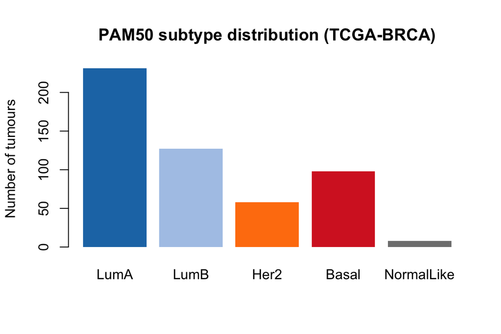

```r
counts <- table(brca$pam50)
barplot(counts[c("LumA","LumB","Her2","Basal","NormalLike")],
        col   = subtype_cols[c("LumA","LumB","Her2","Basal","NormalLike")],
        border = NA,
        ylab  = "Number of tumours",
        main  = "PAM50 subtype distribution (TCGA-BRCA)")
```

> **Question 1.1.** How many tumour samples are in the dataset? Which is the most common PAM50 subtype, and which is the rarest? How do these proportions relate to the most common breast cancer types that are diagnosed clinically?

## Hormone receptor and HER2 status

The PAM50 molecular subtypes were derived from gene expression, but they should correspond closely to the clinical receptor status measured in routine pathology (IHC/FISH staining). These measurements are stored in the `er_status` and `her2_status` columns, while the molecular subtypes are stored in the `pam50` column.

```r
cat("ER status by PAM50 subtype:\n")
```

```
## ER status by PAM50 subtype:
```

```r
print(table(brca$pam50, brca$er_status))
```

```
##
##              Indeterminate Negative Positive
##   Basal                  0       82       14
##   Her2                   2       25       31
##   LumA                   0        7      221
##   LumB                   0        1      126
##   NormalLike             0        2        6
```

```r
cat("\nHER2 status by PAM50 subtype:\n")
```

```
##
## HER2 status by PAM50 subtype:
```

```r
print(table(brca$pam50, brca$her2_status))
```

```
##
##              Equivocal Negative Positive
##   Basal              1       93        2
##   Her2               1       16       39
##   LumA               3      209       14
##   LumB               3      102       20
##   NormalLike         0        8        0
```

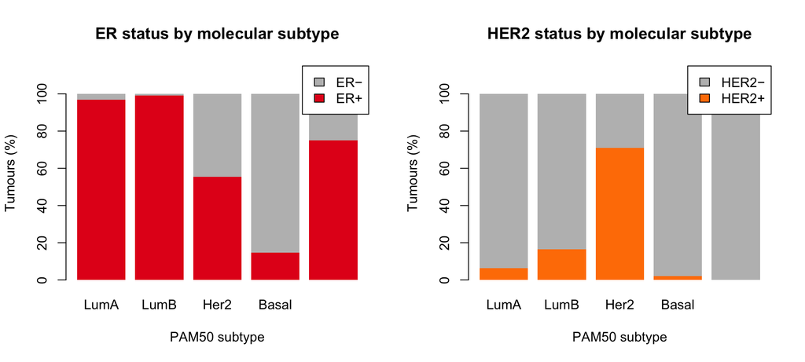

```r
subtype_order <- c("LumA", "LumB", "Her2", "Basal", "NormalLike")

# Keep only Positive/Negative columns (drops rare Indeterminate/Equivocal cases)
tab_er   <- table(brca$pam50, brca$er_status)[subtype_order, c("Positive", "Negative")]
tab_her2 <- table(brca$pam50, brca$her2_status)[subtype_order, c("Positive", "Negative")]

er_pct   <- prop.table(tab_er,   margin = 1) * 100
her2_pct <- prop.table(tab_her2, margin = 1) * 100

par(mfrow = c(1, 2))

barplot(t(er_pct),
        col = c("#e41a1c", "#bdbdbd"), border = NA,
        legend.text = c("ER+", "ER−"), args.legend = list(x = "topright"),
        ylab = "Tumours (%)", xlab = "PAM50 subtype",
        main = "ER status by molecular subtype",
        ylim = c(0, 115))

barplot(t(her2_pct),
        col = c("#ff7f00", "#bdbdbd"), border = NA,
        legend.text = c("HER2+", "HER2−"), args.legend = list(x = "topright"),
        ylab = "Tumours (%)", xlab = "PAM50 subtype",
        main = "HER2 status by molecular subtype",
        ylim = c(0, 115))
```

```r
par(mfrow = c(1, 1))
```

> **Question 1.2.** What tumour types (defined by PAM50) are predominantly ER-positive by IHC/FISH? What tumour types are HER2-positive? How about basal-like tumours? What does this correspondence — or any discordance — tell you about the relationship between the molecular subtype (RNA-based) and routine pathology testing (protein-based)?

> **Question 1.3.** What is the profile of basal-like tumours? Does it make sense in light of the fact that most basal-like tumours are triple-negative breast cancers (TNBC)?

## Distributions of key gene markers

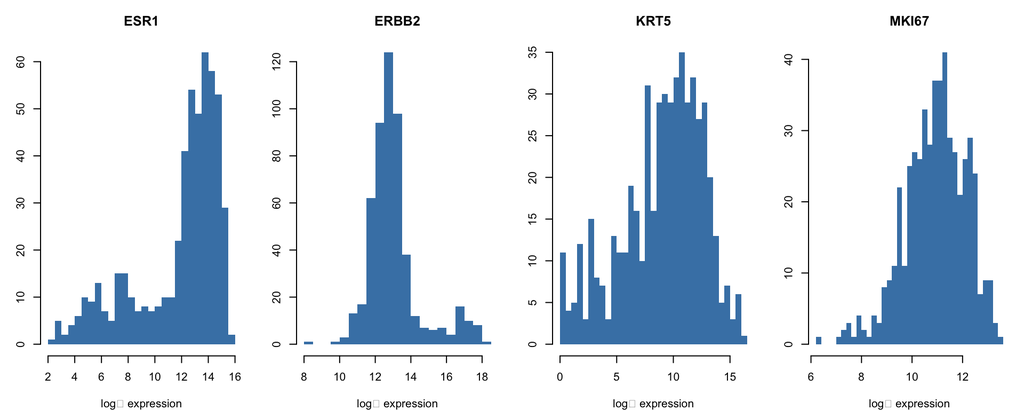

```r
key_genes <- c("ESR1", "ERBB2", "KRT5", "MKI67")
par(mfrow = c(1, 4), mar = c(4, 3, 3, 1))
for (g in key_genes) {
  hist(brca[[g]], breaks = 30, col = "steelblue", border = NA,
       main = g, xlab = "log₂ expression")
}
```

```r
par(mfrow = c(1, 1))
```

> **Question 1.4.** Do any of these four genes show a **bimodal** distribution (two peaks rather than one)? What would a bimodal distribution suggest about the tumour population — could it reflect a mixture of two molecularly distinct groups?

## Gene–gene correlation

Genes in the same biological pathway tend to be co-expressed. We can visualise this with a correlation heatmap.

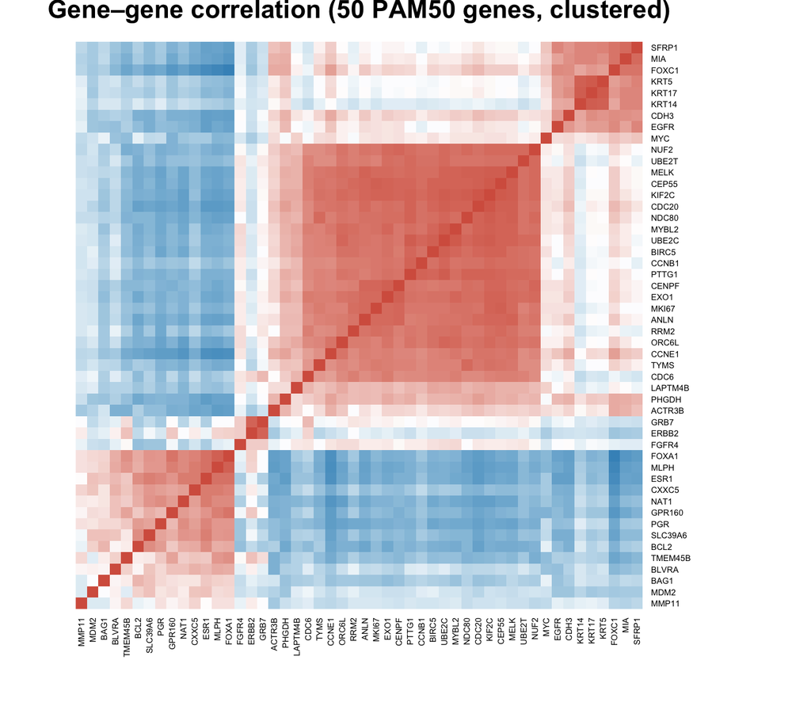

```r
cor_mat  <- cor(brca[, gene_cols], use = "complete.obs")
col_heat <- colorRampPalette(c("#4393c3", "white", "#d6604d"))(100)

# Hierarchical clustering to reorder genes so co-expressed blocks appear together
gene_dist <- as.dist(1 - cor_mat)
gene_clust <- hclust(gene_dist, method = "average")
gene_order <- gene_clust$order

heatmap(cor_mat[gene_order, gene_order],
        Rowv = NA, Colv = NA,      # order already set; suppress re-clustering
        col  = col_heat,
        scale = "none",
        margins = c(6, 6),
        cexRow = 0.6, cexCol = 0.6,
        main = "Gene–gene correlation (50 PAM50 genes, clustered)")
```

> **Question 1.5.** After hierarchical clustering, genes with similar expression patterns across tumours are grouped together and appear as red blocks along the diagonal. Can you identify at least two distinct blocks? What biological programme could each block represent, and why would genes in the same programme tend to be co-expressed?

# 2 — Standardisation

PCA finds the directions of **maximum variance**. If one gene has a much larger spread than another, it will dominate the PCA result simply because of its larger variance — not because it is more biologically informative.

```r
gene_sds <- apply(brca[, gene_cols], 2, sd, na.rm = TRUE)
cat("Standard deviation of each gene (before scaling):\n")
```

```
## Standard deviation of each gene (before scaling):
```

```r
print(round(sort(gene_sds, decreasing = TRUE), 2))
```

```
##    KRT5   KRT14     PGR    ESR1   KRT17   SFRP1     MIA    NAT1   FOXA1 TMEM45B
##    3.62    3.58    3.41    3.21    3.20    2.99    2.96    2.79    2.60    2.35
##    MLPH   FGFR4    CDH3    EGFR   FOXC1 SLC39A6   PHGDH   MYBL2   MMP11   CCNE1
##    2.35    2.18    2.06    2.00    1.99    1.79    1.78    1.71    1.67    1.59
##    BCL2   ERBB2   UBE2C   BIRC5  GPR160    GRB7    EXO1   ORC6L    CDC6   CDC20
##    1.56    1.48    1.43    1.40    1.39    1.37    1.36    1.36    1.34    1.34
##    MELK LAPTM4B    NUF2   KIF2C    RRM2    ANLN   CEP55   CXXC5   NDC80     MYC
##    1.33    1.29    1.28    1.27    1.25    1.24    1.23    1.22    1.21    1.20
##   MKI67   PTTG1   CENPF    TYMS   UBE2T   BLVRA  ACTR3B   CCNB1    BAG1    MDM2
##    1.20    1.17    1.13    1.10    1.09    0.96    0.93    0.92    0.84    0.75
```

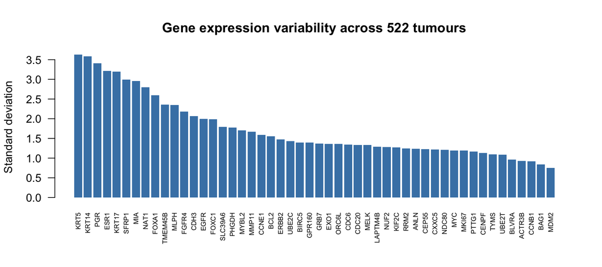

```r
barplot(sort(gene_sds, decreasing = TRUE),
        las = 2, cex.names = 0.6,
        col = "steelblue", border = NA,
        ylab = "Standard deviation",
        main = "Gene expression variability across 522 tumours")
```

```r
X <- scale(brca[, gene_cols])    # standardise to mean 0, sd 1
round(apply(X, 2, mean), 3)[1:5] # confirm: first 5 means ≈ 0
```

```
##   NDC80   ERBB2 TMEM45B   KRT14    BCL2
##       0       0       0       0       0
```

```r
round(apply(X, 2, sd),   3)[1:5] # confirm: first 5 sds = 1
```

```
##   NDC80   ERBB2 TMEM45B   KRT14    BCL2
##       1       1       1       1       1
```

> **Question 2.1.** Before scaling, which gene has the largest standard deviation? Would it be fair to let this gene dominate PC1 just because it happens to vary more than others — or should every gene have equal weight in finding the major axes of biological variation?

> **Question 2.2.** Note that the data are already on a log₂ scale (range ≈ 0–18), so the *units* are already harmonised. Yet the standard deviations still differ by a factor of ~5 across genes. Does this mean log-transformation is enough on its own, or is standardisation a separate and necessary step?

# 3 — Running PCA

## Computing the principal components

`prcomp()` rotates the data so that PC1 captures as much variance as possible, PC2 captures as much of the *remaining* variance as possible, and so on. With 50 input genes, we get 50 principal components in total.

```r
pca <- prcomp(X, scale. = FALSE)   # already scaled above
summary(pca)$importance[, 1:8]     # show first 8 PCs
```

```
##                             PC1      PC2     PC3      PC4      PC5     PC6
## Standard deviation     4.606817 2.723226 1.71192 1.570788 1.155386 1.07164
## Proportion of Variance 0.424460 0.148320 0.05861 0.049350 0.026700 0.02297
## Cumulative Proportion  0.424460 0.572770 0.63139 0.680740 0.707430 0.73040
##                             PC7      PC8
## Standard deviation     1.040426 1.008373
## Proportion of Variance 0.021650 0.020340
## Cumulative Proportion  0.752050 0.772390
```

## Scree plot — how many PCs matter?

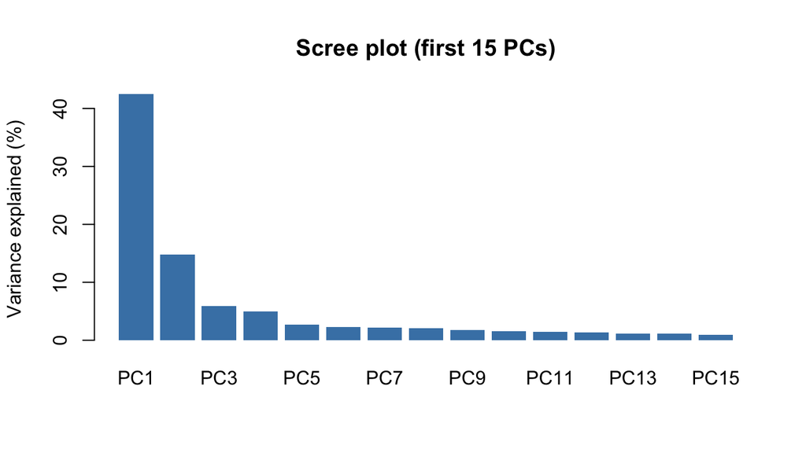

```r
var_exp <- pca$sdev^2 / sum(pca$sdev^2) * 100

barplot(var_exp[1:15],
        names.arg = paste0("PC", 1:15),
        col = "steelblue", border = NA,
        ylab = "Variance explained (%)",
        main = "Scree plot (first 15 PCs)")
```

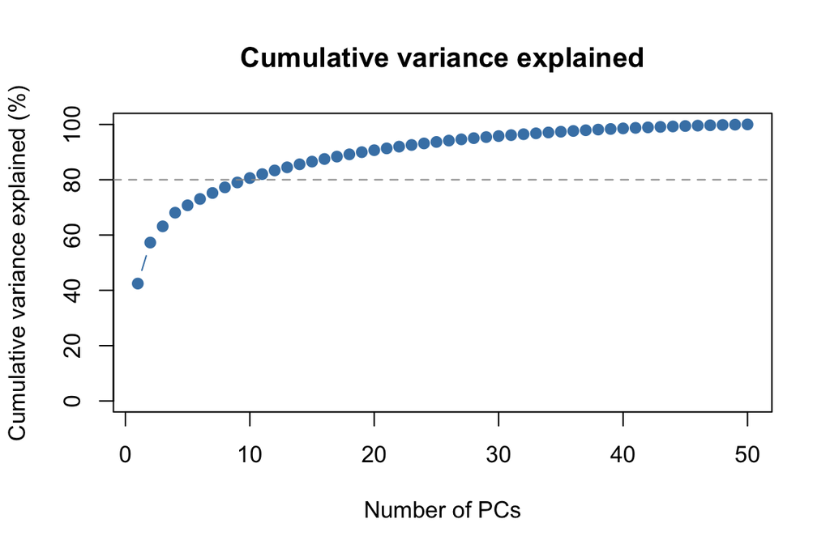

```r
plot(cumsum(var_exp), type = "b", pch = 19, col = "steelblue",
     xlab = "Number of PCs", ylab = "Cumulative variance explained (%)",
     main = "Cumulative variance explained", ylim = c(0, 100))
abline(h = 80, lty = 2, col = "grey60")
```

> **Question 3.1.** How much variance (%) does PC1 alone explain? Given that we started with 50 genes, is it surprising that a single axis can capture such a large fraction of the total variation? What does this suggest about the redundancy among the 50 PAM50 genes?

> **Question 3.2.** How many PCs are needed to capture at least 80 % of the total variance? Is there a clear “elbow” in the scree plot, i.e. a point where adding another PC gives sharply diminishing returns? What does this suggest about how many truly independent sources of variation exist in these 50 genes?

# 4 — Tumours in PCA space

## The PCA plot coloured by PAM50 subtype

Each tumour becomes a **single point** in PCA space. Tumours close together have similar gene expression profiles; tumours far apart are molecularly distinct. Crucially, the PCA was computed with **no knowledge of the subtype labels** — we now colour the points by subtype to see whether PCA rediscovers the biological structure.

```r
scores <- as.data.frame(pca$x)
scores$subtype <- factor(brca$pam50,
                         levels = c("LumA","LumB","Her2","Basal","NormalLike"))
col_pts <- subtype_cols[as.character(scores$subtype)]
```

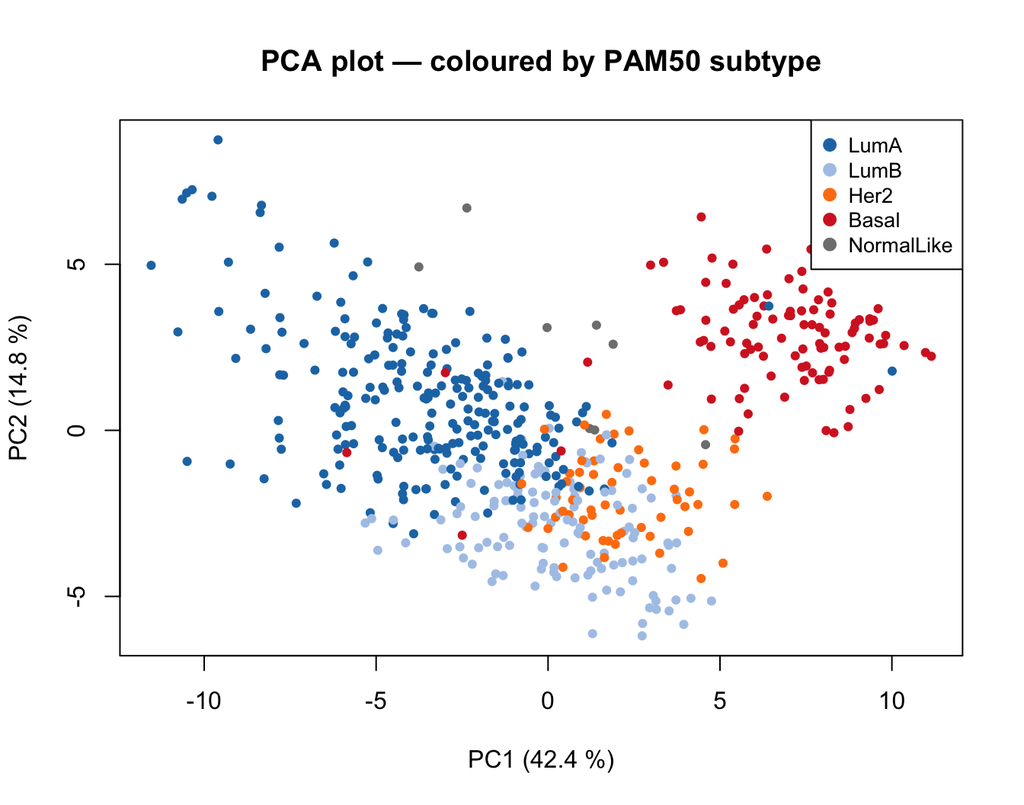

```r
plot(scores$PC1, scores$PC2,
     col  = col_pts, pch = 19, cex = 0.7,
     xlab = paste0("PC1 (", round(var_exp[1], 1), " %)"),
     ylab = paste0("PC2 (", round(var_exp[2], 1), " %)"),
     main = "PCA plot — coloured by PAM50 subtype")
legend("topright",
       legend = names(subtype_cols),
       col    = subtype_cols,
       pch = 19, cex = 0.85, pt.cex = 1.1)
```

> **Question 4.1.** Do the five PAM50 subtypes separate in PCA space? Which subtypes occupy the most distinct, non-overlapping regions? Which subtypes show the most overlap? Is this consistent with the clinical observation that Luminal A and Luminal B tumours are biologically more similar to each other than to Basal-like tumours?

> **Question 4.2.** Along which axis (PC1 or PC2, or both) do the Luminal and Basal tumours separate most clearly? Where do HER2-enriched tumours sit relative to these two poles? Does the arrangement suggest that the major axis of variation in breast cancer gene expression corresponds to the ER+/ER− distinction?

## Mapping individual genes onto the PCA

We colour the same PCA plot by the expression of specific marker genes to reveal which genes explain tumour positions along each PC axis.

```r
map_color <- function(x, n = 100) {
  pal <- colorRampPalette(c("navy", "white", "firebrick"))(n)
  idx <- cut(x, breaks = n, labels = FALSE, include.lowest = TRUE)
  pal[idx]
}
```

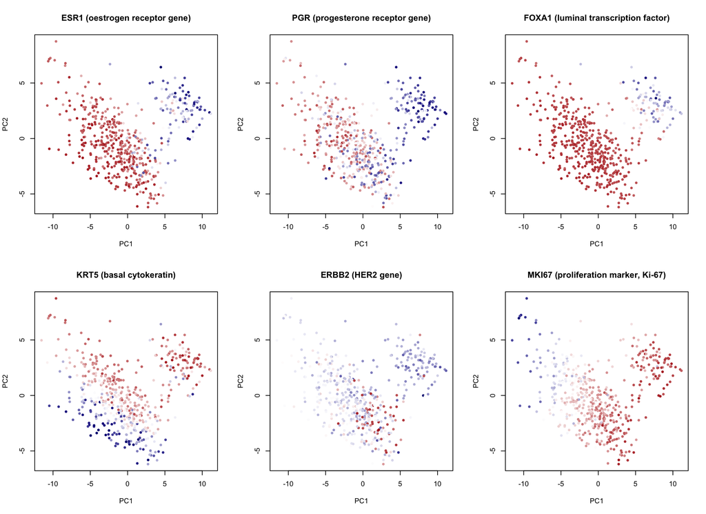

```r
par(mfrow = c(2, 3))

plot(scores$PC1, scores$PC2, pch = 19, cex = 0.6,
     col  = map_color(brca$ESR1),
     main = "ESR1 (oestrogen receptor gene)",
     xlab = "PC1", ylab = "PC2")

plot(scores$PC1, scores$PC2, pch = 19, cex = 0.6,
     col  = map_color(brca$PGR),
     main = "PGR (progesterone receptor gene)",
     xlab = "PC1", ylab = "PC2")

plot(scores$PC1, scores$PC2, pch = 19, cex = 0.6,
     col  = map_color(brca$FOXA1),
     main = "FOXA1 (luminal transcription factor)",
     xlab = "PC1", ylab = "PC2")

plot(scores$PC1, scores$PC2, pch = 19, cex = 0.6,
     col  = map_color(brca$KRT5),
     main = "KRT5 (basal cytokeratin)",
     xlab = "PC1", ylab = "PC2")

plot(scores$PC1, scores$PC2, pch = 19, cex = 0.6,
     col  = map_color(brca$ERBB2),
     main = "ERBB2 (HER2 gene)",
     xlab = "PC1", ylab = "PC2")

plot(scores$PC1, scores$PC2, pch = 19, cex = 0.6,
     col  = map_color(brca$MKI67),
     main = "MKI67 (proliferation marker, Ki-67)",
     xlab = "PC1", ylab = "PC2")
```

```r
par(mfrow = c(1, 1))
```

*In all plots: blue = low expression, red = high expression.*

> **Question 4.3.** ESR1 is the gene encoding the oestrogen receptor, which drives growth in Luminal tumours; KRT5 is a structural protein expressed in basal/myoepithelial cells. What can we say about the expression of these two genes from the PCA plot?

> **Question 4.4.** Where do tumours with high *ERBB2* expression sit in PCA space? What breast cancer subtypes has the highest expression of *ERBB2*?

> **Question 4.5.** *MKI67* (which encodes Ki-67, a widely used clinical proliferation marker) is elevated in which region of PCA space? Is proliferation higher in Luminal A or Luminal B tumours? This mirrors a key clinical difference between the two Luminal subtypes — Luminal B is more proliferative and carries a worse prognosis.

# 5 — Loadings and the Biplot

## Variable loadings

The **loadings** (in `pca$rotation`) tell us how much each gene contributes to each PC. A large positive loading means that tumours with high expression of that gene sit at the *positive* end of the PC; a large negative loading places them at the *negative* end.

```r
# Top 10 genes by absolute loading on PC1 and PC2
top_pc1 <- sort(pca$rotation[, 1])[c(1:5, 46:50)]   # 5 most negative, 5 most positive
top_pc2 <- sort(pca$rotation[, 2])[c(1:5, 46:50)]
cat("Top genes on PC1:\n"); print(round(top_pc1, 3))
```

```
## Top genes on PC1:
```

```
##   MLPH   ESR1  FOXA1   NAT1    PGR  NDC80   MELK  CEP55  KIF2C  CDC20
## -0.161 -0.158 -0.154 -0.146 -0.142  0.191  0.193  0.194  0.198  0.199
```

```r
cat("\nTop genes on PC2:\n"); print(round(top_pc2, 3))
```

```
##
## Top genes on PC2:
```

```
##  FOXA1  CXXC5   CDC6   MLPH   ESR1  KRT14  KRT17  FOXC1    MIA  SFRP1
## -0.195 -0.171 -0.170 -0.166 -0.155  0.245  0.248  0.258  0.265  0.285
```

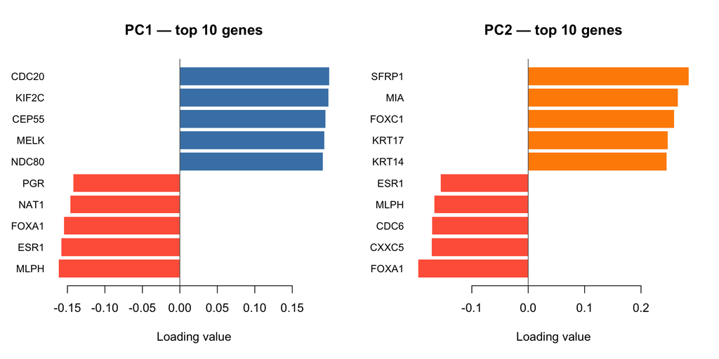

```r
n_show <- 10   # top 5 positive + top 5 negative

pick_top <- function(loadings, n) {
  s <- sort(loadings)
  c(head(s, n %/% 2), tail(s, n %/% 2))
}

par(mfrow = c(1, 2))

top1 <- pick_top(pca$rotation[, 1], n_show)
barplot(top1, horiz = TRUE, las = 1, cex.names = 0.85,
        col = ifelse(top1 > 0, "steelblue", "tomato"), border = NA,
        main = "PC1 — top 10 genes", xlab = "Loading value")
abline(v = 0, col = "grey40")

top2 <- pick_top(pca$rotation[, 2], n_show)
barplot(top2, horiz = TRUE, las = 1, cex.names = 0.85,
        col = ifelse(top2 > 0, "darkorange", "tomato"), border = NA,
        main = "PC2 — top 10 genes", xlab = "Loading value")
abline(v = 0, col = "grey40")
```

```r
par(mfrow = c(1, 1))
```

> **Question 5.1.** Looking at the PC1 loading barplot: which genes have the strongest **positive** loadings, and which have the strongest **negative** loadings? Based on their known biology, propose a possible interpretation for the PC1 axis.

## The biplot — patients and variables in one figure

So far we have looked at patient positions (PCA plot) and variable contributions (loading bars) separately. A **biplot** combines both into a single figure: patient positions are shown as dots (or abbreviated row labels), and each variable is drawn as an **arrow** originating from the centre.

**How to read a biplot:**

| Feature | What it means |
| --- | --- |
| **Arrow length** | How much this variable contributes to the visible PCs — a long arrow means the variable is well represented in this 2-D view |
| **Arrow direction** | Tumours in the direction of the arrow have high values for this gene |
| **Angle between two arrows** | Near 0° = the genes are positively correlated; near 180° = negatively correlated; near 90° = uncorrelated |
| **Distance from centre** | Tumours near the centre are close to average for most genes; extreme tumours at the edges are unusual |

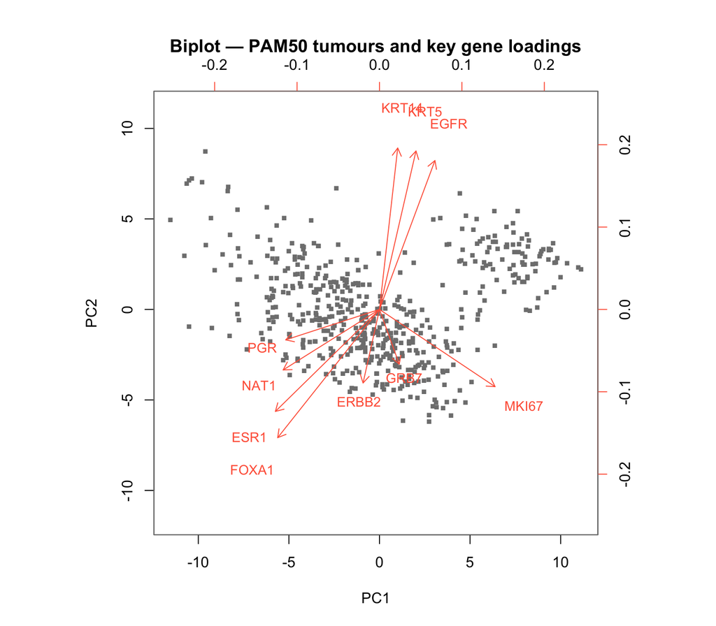

```r
# Hand-picked panel covering the main biological axes
panel_genes <- c("ESR1", "PGR", "FOXA1", "NAT1",   # hormone / luminal
                 "KRT5", "KRT14", "EGFR",            # basal
                 "ERBB2", "GRB7",                    # HER2 amplicon
                 "MKI67")                            # proliferation

pca_sub          <- pca
pca_sub$rotation <- pca$rotation[panel_genes, , drop = FALSE]

# xlabs = "." replaces each sample label with a dot
biplot(pca_sub, scale = 0,
       xlabs = rep(".", nrow(pca$x)),
       cex   = c(3.0, 0.9),
       col   = c("grey50", "tomato"),
       main  = "Biplot — PAM50 tumours and key gene loadings")
```

> **Question 5.2.** In the biplot, do the arrows for hormone-receptor genes (*ESR1*, *PGR*, *FOXA1*) and basal markers (*KRT5*, *KRT14*, *EGFR*) point in roughly *opposite* directions? Luminal tumours are ER-positive with high hormone signalling; Basal-like tumours are ER-negative with high expression of basal keratins. Does the biplot geometry reflect this biological opposition?

> **Question 5.3.** Which genes load most strongly on PC2? Based on those genes, what biological programme might PC2 be capturing?

> **Question 5.4.** Some arrows are short and others are long. A short arrow means the gene’s variation is not well captured in the PC1–PC2 plane — it contributes mainly to higher PCs. Does this mean short-arrow genes are biologically unimportant, or just that their variation aligns with a different axis than the first two?

# 6 — UMAP: a non-linear alternative to PCA

## What UMAP does differently

PCA finds **linear** combinations of variables that capture maximum variance. Its great strength is interpretability: PCs are explicit weighted sums of the original variables, and variance explained gives an objective measure of information captured.

However, PCA has a fundamental constraint: it can only represent data variation that lies along straight axes. When the true structure of the data is curved or folded in high-dimensional space — as is common in complex biological systems — PCA may “flatten” that structure in a way that blurs distinct groups together.

**UMAP** (Uniform Manifold Approximation and Projection) takes a different approach. Instead of maximising variance, it tries to **preserve the local neighbourhood structure** of the data: points that are close together in the original 50-dimensional gene space should still be close together in the 2-D projection. UMAP is particularly good at revealing compact, well-separated clusters that PCA might present as blended clouds.

Key differences:

|  | PCA | UMAP |
| --- | --- | --- |
| Approach | Linear rotation | Non-linear graph embedding |
| What it preserves | Global variance structure | Local neighbourhood relationships |
| Axes interpretation | PCs have explicit gene weights | Axes have no direct meaning |
| Variance explained | Defined and quantifiable | Not defined |
| Reproducibility | Deterministic | Sensitive to random seed and parameters |
| Speed | Very fast | Slower, especially on large datasets |

```r
library(uwot)

set.seed(42)
umap_coords <- umap(X,
                    n_neighbors = 15,
                    min_dist    = 0.2,
                    metric      = "euclidean",
                    verbose     = FALSE)

umap_df <- data.frame(UMAP1 = umap_coords[, 1],
                      UMAP2 = umap_coords[, 2],
                      subtype = scores$subtype)
```

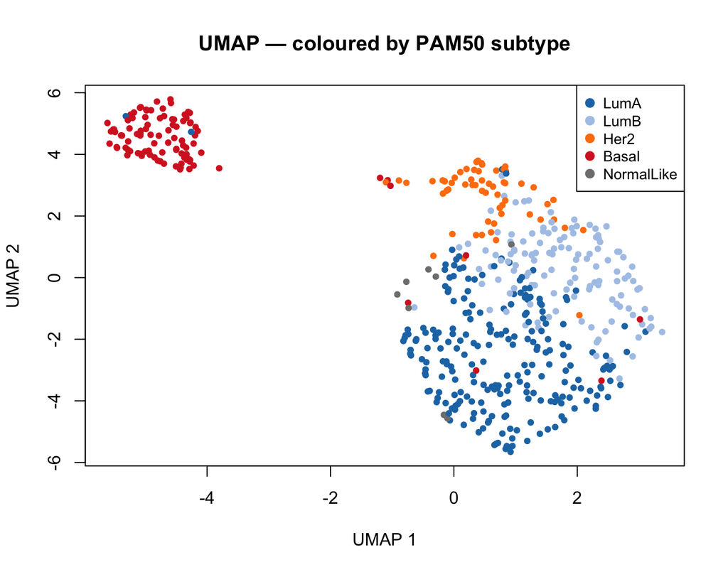

```r
col_umap <- subtype_cols[as.character(umap_df$subtype)]

plot(umap_df$UMAP1, umap_df$UMAP2,
     col = col_umap, pch = 19, cex = 0.7,
     xlab = "UMAP 1", ylab = "UMAP 2",
     main = "UMAP — coloured by PAM50 subtype")
legend("topright",
       legend = names(subtype_cols),
       col    = subtype_cols,
       pch = 19, cex = 0.85, pt.cex = 1.1)
```

## Side-by-side comparison

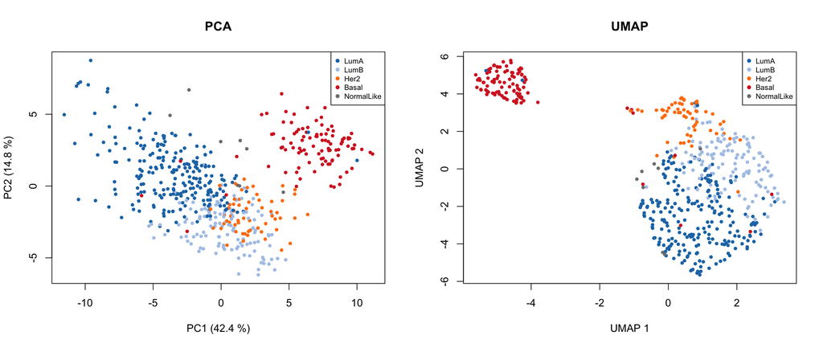

```r
par(mfrow = c(1, 2))

plot(scores$PC1, scores$PC2,
     col = col_pts, pch = 19, cex = 0.6,
     xlab = paste0("PC1 (", round(var_exp[1], 1), " %)"),
     ylab = paste0("PC2 (", round(var_exp[2], 1), " %)"),
     main = "PCA")
legend("topright", legend = names(subtype_cols),
       col = subtype_cols, pch = 19, cex = 0.7)

plot(umap_df$UMAP1, umap_df$UMAP2,
     col = col_umap, pch = 19, cex = 0.6,
     xlab = "UMAP 1", ylab = "UMAP 2",
     main = "UMAP")
legend("topright", legend = names(subtype_cols),
       col = subtype_cols, pch = 19, cex = 0.7)
```

```r
par(mfrow = c(1, 1))
```

> **Question 6.1.** Compare the PCA and UMAP plots side by side. Which method produces more compact, better-separated clusters for the PAM50 subtypes? Are the same subtypes that overlapped in PCA (e.g. Luminal A and Luminal B) still mixed in UMAP, or does UMAP pull them apart?

> **Question 6.2.** In UMAP, do the five subtypes appear as visually distinct islands, or do they form a continuous gradient? What does the answer suggest about whether breast cancer subtypes are truly discrete categories or points along a biological continuum?

> **Question 6.3.** The UMAP axes (UMAP 1, UMAP 2) have no direct biological interpretation — you cannot look up “what genes drive UMAP 1” the way you can look up PC1 loadings. What is the practical implication of this for clinical use — would you trust a UMAP-based clustering result without additional validation?

> **Question 6.4.** Run the UMAP code chunk again with a different random seed (change `set.seed(42)` to `set.seed(99)`). Does the overall grouping of subtypes remain the same, or does the layout change substantially? What does this tell you about the reproducibility of UMAP compared with PCA?

# 7 — Limitations of PCA

PCA is a powerful and widely used tool, but every method has assumptions and failure modes. Understanding these limitations is as important as knowing how to apply the technique.

## 1. PCA only captures linear relationships

PCA finds axes that maximise **linear** variance. If the true structure of the data lies along a curved surface (imagine patients distributed on the surface of a sphere rather than a flat plane), PCA will “unfold” or distort that surface. The PCA plot may show groups that are actually distinct as an overlapping cloud.

**When this matters:** data from development (cell differentiation along a trajectory), disease progression along a non-linear path, or any scenario where groups form arcs rather than blobs.

**What to do:** use non-linear methods such as UMAP (as in section 6), t-SNE, or diffusion maps.

## 2. Variance ≠ biological importance

PCA maximises **variance**, not **clinical relevance**. The direction that accounts for the most spread in the data may be dominated by: - **Technical noise** (batch effects from different labs or sequencing runs) - **Unwanted biological variation** (e.g. tumour purity, cell cycle state) rather than the signal of interest (e.g. subtype identity, prognosis).

**Example:** in RNA-seq data, PC1 is sometimes dominated by sequencing depth or library composition — artefacts that should be removed before applying PCA to biological questions.

**What to do:** always interpret PCs biologically before trusting them. Check whether known batch variables correlate with early PCs, and regress them out if needed.

## 3. Sign ambiguity

The **direction** of a PC axis (which end is positive, which is negative) is mathematically arbitrary: PCA could flip any axis and the result would be equally valid. This means:

- A positive PC1 score does not inherently mean “sicker” or “more expressive” — it depends on the sign of the loadings, which could be opposite in a different run or on a different dataset.
- When comparing PCA from two different datasets, the signs of corresponding PCs may be flipped.

**What to do:** always anchor interpretation in the loadings, not in the sign of the score.

## 4. Sensitivity to outliers

PCA is based on variance, which is sensitive to extreme values. A single patient with an unusual measurement can pull the first PC toward their position, reducing the informativeness of PC1 for the rest of the cohort.

**What to do:** check for outliers before running PCA (histograms, boxplots); consider robust PCA methods for datasets with frequent outliers.

## 5. The number of PCs to retain is a judgement call

The scree plot elbow is useful, but it is subjective. Different researchers looking at the same scree plot may choose different cutoffs. There is no universally correct answer; the right number of PCs depends on the downstream analysis and the biological question.

> **Question 7.1.** In the BRCA dataset, could any of the above limitations apply? For example: could there be technical variation (batch effects) that PCA might pick up before biological subtype differences? How would you check for this?

> **Question 7.2.** Compare the PCA and UMAP plots for this dataset. Is there a region of PCA space where distinct subtypes are blended together, but UMAP separates them? This would suggest that the true cluster boundary in gene-expression space is non-linear — a case where PCA’s linearity limitation matters.

> **Question 7.3.** Given all the limitations above, would you use PCA alone to classify a new patient’s tumour into a PAM50 subtype? Or would you use it as a first exploration step before applying a more targeted classifier? What is the appropriate clinical role for PCA in oncology?

# 8 — Wrap-up

> **Question 8.1 (wrap-up).** In four or five sentences, summarise the key findings: How well do the first two principal components separate the five PAM50 subtypes, and what biological programmes do PC1 and PC2 represent? What does the biplot add to the interpretation of PCA that the loading barplots alone cannot convey? How does UMAP compare with PCA for visualising this dataset? And which of PCA’s limitations is most relevant to interpreting these breast cancer results?